# Social Media Sentiment Analysis vs. President Trump's Approval Rate

(These are only part of our project that can be shown in notebook with small dataset)

```python
#Setup Environment
import pandas as pd
import numpy as np
import matplotlib.pyplot as plt
import re
import time
import json
from vaderSentiment.vaderSentiment import SentimentIntensityAnalyzer as sa
from nltk.stem import WordNetLemmatizer
import nltk
from nltk.corpus import stopwords
from sklearn.feature_extraction.text import TfidfVectorizer
from sklearn.feature_extraction.text import CountVectorizer
from sklearn import preprocessing
from sklearn.model_selection import train_test_split
from sklearn.metrics import accuracy_score
from sklearn.naive_bayes import MultinomialNB
from sklearn.linear_model import SGDClassifier
from sklearn.linear_model import LogisticRegression
from sklearn.ensemble import RandomForestClassifier
import pickle
import warnings
from sklearn.model_selection import cross_val_score
from sklearn import linear_model
from sklearn.tree import DecisionTreeRegressor
from sklearn import metrics
import seaborn as sn
warnings.filterwarnings('ignore')
```

### #1 NLP Text Preprocessing

```python
#Define Data Cleaning functions
def unification(data_cleaned):
    #Making all letters lowercase
    data_cleaned['text'] = data_cleaned['text'].apply(lambda x: x.lower())
    #Removing Punctuation, Symbols
    data_cleaned['text'] = data_cleaned['text'].str.replace('[^\w\s]',' ')
    #Removing Stop Words
    stop_words = stopwords.words('english')
    for i in range(len(data_cleaned)):
        text = ''
        for word in data_cleaned.loc[i]['text'].split():
            if word not in stop_words:
                text+=' '+word
        data_cleaned.loc[i]['text'] = text.strip(' ')
    return data_cleaned

def lemmatisation(data_cleaned):
    lemmatizer = WordNetLemmatizer()
    for i in range(len(data_cleaned)):
        text = ''
        for word in data_cleaned.loc[i]['text'].split():
            text+=' '+lemmatizer.lemmatize(lemmatizer.lemmatize(lemmatizer.lemmatize(word),pos = 'a'), pos = 'v')
        data_cleaned.loc[i]['text'] = text.strip(' ')
    return data_cleaned

def removing_rare_words(data_cleaned, num_to_ignore = 5000):
    word_dict = {}
    for i in range(len(data_cleaned)):
        for word in data_cleaned.loc[i]['text'].split():
            if word in word_dict:
                word_dict[word]+=1
            else:
                word_dict[word] = 1
    rarest_words = sorted(list(word_dict.keys()), key = lambda x:word_dict[x])[:num_to_ignore]

    for i in range(len(data_cleaned)):
        text = ''
        for word in data_cleaned.loc[i]['text'].split():
            if word not in rarest_words:
                text+=' '+word
        data_cleaned.loc[i]['text'] = text.strip(' ')
    return data_cleaned

def data_cleaning(data_cleaned, num_to_ignore = 5000):
    return removing_rare_words(lemmatisation(unification(data_cleaned)), num_to_ignore)


#Show Original Data
anger = pd.read_csv('Train dataset/anger-ratings-0to1.train.txt', sep = '\t', names =  ['id','text','emotion','intensity'])
fear = pd.read_csv('Train dataset/fear-ratings-0to1.train.txt', sep = '\t', names =  ['id','text','emotion','intensity'])
joy = pd.read_csv('Train dataset/joy-ratings-0to1.train.txt', sep = '\t', names =  ['id','text','emotion','intensity'])
sadness = pd.read_csv('Train dataset/sadness-ratings-0to1.train.txt', sep = '\t', names =  ['id','text','emotion','intensity'])
emotion_traning_data = pd.concat([anger, fear, joy, sadness],ignore_index=True)
print("Original Data:")
print(emotion_traning_data.head())
print("\nData After Preprocessing:")
emotion_traning_data_cleaned = emotion_traning_data.drop(['id','intensity'], axis=1)
emotion_traning_data_cleaned = data_cleaning(emotion_traning_data_cleaned)
print(emotion_traning_data_cleaned.head())
```

```
Original Data:
      id                                               text emotion  intensity
0  10000  How the fu*k! Who the heck! moved my fridge!.....   anger      0.938
1  10001  So my Indian Uber driver just called someone t...   anger      0.896
2  10002  @DPD_UK I asked for my parcel to be delivered ...   anger      0.896
3  10003  so ef whichever butt wipe pulled the fire alar...   anger      0.896
4  10004  Don't join @BTCare they put the phone down on ...   anger      0.896

Data After Preprocessing:
                                                text emotion
0                          move knock door angry mad   anger
1  indian uber driver call someone n word move ve...   anger
2                ask deliver pick store address fume   anger
3  whichever butt wipe pull fire alarm bc sound p...   anger
4       join put phone talk rude take money acc fume   anger
```

### #2 Word Embedding, Emotion detectionModel training and Evalutation

Since some of word embedding methods will take too long to fit dataset, we only show TF-IDF and Count Vector here

```python
#Label Encoding and Split dataset
lbl_enc = preprocessing.LabelEncoder()
y = lbl_enc.fit_transform(emotion_traning_data_cleaned.emotion.values)
X_train, X_val, y_train, y_val = train_test_split(emotion_traning_data_cleaned.text.values, y, stratify=y, random_state=23, test_size=0.2, shuffle=True)

#TF-IDF
#TF-IDF is not an ideal word embedding method due to its low accuracy
tfidf = TfidfVectorizer(max_features=5000, analyzer='word',ngram_range=(1,3))
X_train_tfidf = tfidf.fit_transform(X_train)
X_val_tfidf = tfidf.fit_transform(X_val)
print('Count Vector Embedded Text:',X_val_tfidf[0].toarray())

y_pred = MultinomialNB().fit(X_train_tfidf, y_train).predict(X_val_tfidf)
print("TF-IDF with Naive Bayes Classifier:", accuracy_score(y_pred, y_val))


y_pred = SGDClassifier(alpha=0.001, random_state=4, max_iter=35, tol=None).fit(X_train_tfidf, y_train).predict(X_val_tfidf)
print('TF-IDF with SVM:', accuracy_score(y_pred, y_val))


y_pred = LogisticRegression(C=1).fit(X_train_tfidf, y_train).predict(X_val_tfidf)
print('TF-IDF with logistic regression:', accuracy_score(y_pred, y_val))

print('TF-IDF is not an ideal word embedding method due to its low accuracy\n')

#Count Vector with bigram(Our Choice)
count_vect = CountVectorizer(analyzer='word',ngram_range = (1,2))
count_vect.fit(emotion_traning_data_cleaned['text'])
X_train_count =  count_vect.transform(X_train)
X_val_count =  count_vect.transform(X_val)

print('Count Vector Embedded Text:',X_train_count.toarray())

y_pred = MultinomialNB().fit(X_train_count, y_train).predict(X_val_count)
print('Count Vector with Naive Bayes Classifier:', accuracy_score(y_pred, y_val))



y_pred = SGDClassifier(alpha=0.001, random_state=4, max_iter=35, tol=None).fit(X_train_count, y_train).predict(X_val_count)
print('Count Vector with SVM:', accuracy_score(y_pred, y_val))


y_pred = LogisticRegression(C=1).fit(X_train_count, y_train).predict(X_val_count)
print('Count Vector with logistic regression:', accuracy_score(y_pred, y_val))

print('Since the Count Vector with SVM has a good accuracy, \nwe will use this model in later data classification, so we will save this model')

emo_svm = SGDClassifier(alpha=0.001, random_state=4, max_iter=35, tol=None).fit(X_train_count, y_train)
```

```
Count Vector Embedded Text: [[0. 0. 0. ... 0. 0. 0.]]
TF-IDF with Naive Bayes Classifier: 0.26556016597510373
TF-IDF with SVM: 0.25864453665283543
TF-IDF with logistic regression: 0.2821576763485477
TF-IDF is not an ideal word embedding method due to its low accuracy

Count Vector Embedded Text: [[0 0 0 ... 0 0 0]
 [0 0 0 ... 0 0 0]
 [0 0 0 ... 0 0 0]
 ...
 [0 0 0 ... 0 0 0]
 [0 0 0 ... 0 0 0]
 [0 0 0 ... 0 0 0]]
Count Vector with Naive Bayes Classifier: 0.8271092669432918
Count Vector with SVM: 0.8893499308437067
Count Vector with logistic regression: 0.8672199170124482
Since the Count Vector with SVM has a good accuracy,
we will use this model in later data classification, so we will save this model
```

### #3 Data Wrangling and Baseline Simple Linear Regression

```python
# read emotion data from csv files

# read reddit emotion data from csv file
rd = pd.read_csv('emotion data/rd.csv', index_col = 0)
print('Reddit emotion data sample:\n',rd.sample(5),'\n')
#read twitter emotion data from csv file
td = pd.read_csv('emotion data/td.csv', index_col = 0)
print('twitter emotion data sample:\n',td.sample(5),'\n')
```

```
Reddit emotion data sample:
                anger        app      fear       joy       neg       neu  \
2020-03-01  0.271565  43.324429  0.437700  0.083067  0.389776  0.207668
2020-03-02  0.240793  43.178390  0.501416  0.133144  0.325779  0.294618
2019-12-28  0.250000  42.601538  0.750000  0.000000  0.500000  0.250000
2019-12-18  0.375000  43.370585  0.625000  0.000000  0.875000  0.000000
2019-12-27  0.360000  42.601538  0.430000  0.060000  0.440000  0.250000

              num       pos   sadness    sum_c
2020-03-01  313.0  0.402556  0.207668   2.8871
2020-03-02  353.0  0.379603  0.124646   8.0362
2019-12-28    4.0  0.250000  0.000000  -0.0788
2019-12-18    8.0  0.125000  0.000000  -4.8008
2019-12-27  100.0  0.310000  0.150000 -12.3001

twitter emotion data sample:
                anger        app      fear       joy       neg       neu  \
2020-02-19  0.187500  44.337416  0.500000  0.187500  0.375000  0.250000
2020-04-08  0.291017  44.631565  0.581358  0.035719  0.462969  0.204721
2020-03-15  0.393258  42.613403  0.488140  0.041199  0.425718  0.307116
2020-03-25  0.353261  44.629069  0.505435  0.061141  0.358696  0.330163
2020-01-29  0.238095  42.951310  0.619048  0.047619  0.238095  0.333333

                 num       pos   sadness       sum_c
2020-02-19      16.0  0.375000  0.125000     -2.5234
2020-04-08  168791.0  0.332310  0.091907 -16404.5404
2020-03-15     801.0  0.267166  0.077403    -91.1383
2020-03-25     736.0  0.311141  0.080163    -32.5213
2020-01-29      21.0  0.428571  0.095238      0.6099
```

##### We want to make expnanation of what does our data mean here. The data is calculated percentage of the tweets and reddit posts of each day from the count of each emotion and attitude on that day. For example, the anger column with 0.4 in rd file on one day means 40% of tweets on that day is with the emotion of anger. The num is the total number of data on that day, the pos, neg, neu, sum_c were got from VADER package, since we will not use these features, we will just drop them off. The app column is the approval rate of Trump on that day from FiveThirtyEight polls results.

```python
rd = rd.drop(['neg', 'pos', 'neu', 'sum_c'], axis=1)
print('Reddit emotion data sample with unused feature dropped:\n',rd.sample(5),'\n')
td = td.drop(['neg', 'pos', 'neu', 'sum_c'], axis=1)
print('twitter emotion data sample with unused feature dropped:\n',td.sample(5),'\n')
```

```
Reddit emotion data sample with unused feature dropped:
                anger        app      fear       joy     num   sadness
2020-01-11  0.353535  41.788103  0.474747  0.070707    99.0  0.101010
2020-01-22  0.297619  41.909656  0.541667  0.107143   168.0  0.053571
2020-03-21  0.253344  43.182827  0.529504  0.121951  1271.0  0.095201
2020-02-12  0.245675  43.462463  0.546713  0.065744   289.0  0.141869
2020-04-28  0.259149  42.599133  0.527122  0.099403  7706.0  0.114326

twitter emotion data sample with unused feature dropped:
                anger        app      fear       joy      num   sadness
2020-04-28  0.282325  42.599133  0.604302  0.031271  93920.0  0.082102
2020-03-23  0.365410  43.685175  0.482445  0.048114    769.0  0.104031
2020-01-26  0.200000  43.074199  0.714286  0.000000     35.0  0.085714
2020-03-06  0.321586  42.759827  0.539648  0.037445    454.0  0.101322
2020-03-21  0.356083  43.182827  0.500000  0.059347    674.0  0.084570
```

##### Since some of the date are apprantly not related to this pandemic and some of days have very few data, so we only care about the date with reasonable amount of data and consecutive in later days.

```python
#Record needed date of Reddit
reddit_dl = []
for d in range(len(rd)):
    if rd.iloc[d]['num']>50:
        reddit_dl.append(rd.iloc[d])

reddit_dl = reddit_dl[14:]
rd = pd.DataFrame(reddit_dl)

#Record needed date of Twitter
twitter_dl = []
for d in range(len(td)):
    if td.iloc[d]['num']>100:
        twitter_dl.append(td.iloc[d])

td = pd.DataFrame(twitter_dl)
```

##### Now we are going to show the simple linear regression model! (attention: This is not our ideal model, this model is for baseline comparative to show how well the later models work)

```python
#build model with reddit
X_r, y_r = rd.drop(['app'], axis=1)*10, rd.app
X_train, X_test, y_train, y_test = train_test_split(X_r, y_r, test_size=0.2, random_state=1234)
model_r = linear_model.LinearRegression()
model_r.fit(X_train, y_train)
y_test_pred = model_r.predict(X_test)
print("RMSE of simple linear regression with Reddit test data:", np.sqrt(metrics.mean_squared_error(y_test, y_test_pred)))
print("MSE of simple linear regression with Reddit test data:", metrics.mean_squared_error(y_test, y_test_pred))
print("R^2 of simple linear regression with Reddit test data:", metrics.r2_score(y_test, y_test_pred))
```

```
RMSE of simple linear regression with Reddit test data: 0.7371369938112529
MSE of simple linear regression with Reddit test data: 0.5433709476450911
R^2 of simple linear regression with Reddit test data: 0.18897608018561818
```

```python
#build model with twitter
X_t, y_t = td.drop(['app'], axis=1)*10, td.app
X_train, X_test, y_train, y_test = train_test_split(X_t, y_t, test_size=0.2, random_state=1234)
model_t = linear_model.LinearRegression()
model_t.fit(X_train, y_train)
y_test_pred = model_t.predict(X_test)
print("RMSE of simple linear regression with Twitter test data:", np.sqrt(metrics.mean_squared_error(y_test, y_test_pred)))
print("MSE of simple linear regression with Twitter test data:", metrics.mean_squared_error(y_test, y_test_pred))
print("R^2 of simple linear regression with Twitter test data:", metrics.r2_score(y_test, y_test_pred))
```

```
RMSE of simple linear regression with Twitter test data: 0.873370569103457
MSE of simple linear regression with Twitter test data: 0.7627761509760964
R^2 of simple linear regression with Twitter test data: 0.3052885332328579
```

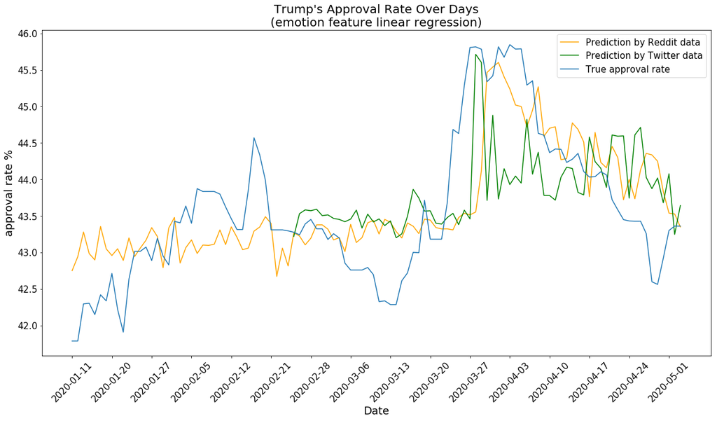

```python
#Plot the over all curve to see how badly it fits
lr_pred = pd.concat([pd.Series(model_r.predict(X_r)),pd.Series(pd.concat([pd.Series([np.nan]*(len(X_r)-len(X_t))), pd.Series(model_t.predict(X_t))]).reset_index(drop = True)), y_r.reset_index(drop = True)], axis = 1)
lr_pred.columns = ['r_p', 't_p', 'app']
lr_pred.index = y_r.index
fig, ax = plt.subplots(1, figsize = (20,10))
plt.plot(lr_pred.r_p, c = 'orange', label = 'Prediction by Reddit data')
plt.plot(lr_pred.t_p, c = 'green', label = 'Prediction by Twitter data')
plt.plot(lr_pred.app, label = 'True approval rate')
tic = []
labe = []
for i in range(len(lr_pred.index)):
    if i % 7 == 0:
        tic.append(lr_pred.index[i])
        labe.append(str(lr_pred.index[i])[:10])
plt.xticks(tic, labe, rotation = 45,fontsize = '15')
plt.yticks(fontsize = '15')
plt.xlabel('Date', fontsize = '18')
plt.ylabel('approval rate %', fontsize = '18')
plt.title('Trump\'s Approval Rate Over Days\n(emotion feature linear regression)', fontsize = '20')
plt.legend(fontsize = 15)
plt.show()
```

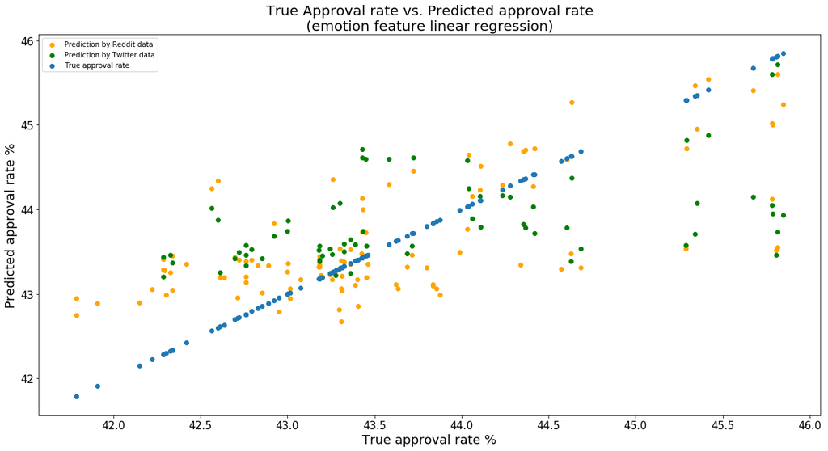

```python
fig, ax = plt.subplots(1, figsize = (20,10))
plt.scatter(lr_pred.app,lr_pred.r_p, c = 'orange', label = 'Prediction by Reddit data')
plt.scatter(lr_pred.app,lr_pred.t_p, c = 'green', label = 'Prediction by Twitter data')
plt.scatter(lr_pred.app,lr_pred.app , label = 'True approval rate')
plt.xlabel('True approval rate %', fontsize = '18')
plt.ylabel('Predicted approval rate %', fontsize = '18')
plt.yticks(fontsize = '15')
plt.xticks(fontsize = '15')
plt.title('True Approval rate vs. Predicted approval rate\n(emotion feature linear regression)', fontsize = '20')
plt.legend()
plt.show()
```

##### So we will give out two our advanced model now!

### #4 Autoregressive Model with Emotion Classification data

##### We used the approval rate of this day to help predict the approval rate of next day, this intuition is to using the recent approval rate as a baseline and using the emotion features to explain the difference of approval rate.

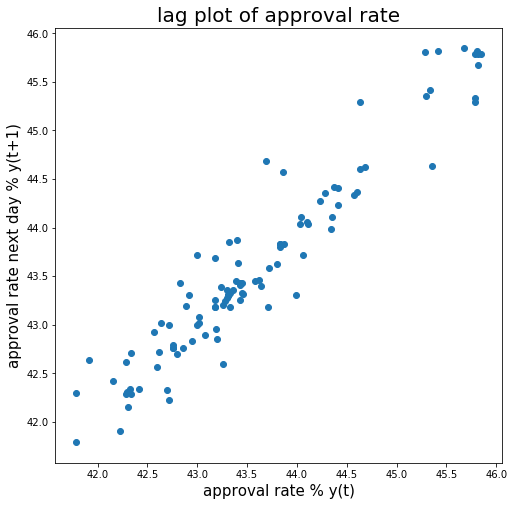

```python
plt.figure(figsize = (8,8))
pd.plotting.lag_plot(rd.app)
plt.xlabel("approval rate % y(t)", fontsize = 15)
plt.ylabel("approval rate next day % y(t+1)", fontsize = 15)
plt.title("lag plot of approval rate",fontsize = 20)
plt.show()
```

##### From this lag plot we can see a strong correlation between two days' approval rate and this helped prove our assumption

```python
# Data Preparation
rd = pd.read_csv('emotion data/rd.csv', index_col = 0)
td = pd.read_csv('emotion data/td.csv', index_col = 0)

rd = rd.drop(['neg', 'pos', 'neu', 'sum_c'], axis=1)
td = td.drop(['neg', 'pos', 'neu', 'sum_c'], axis=1)

rd_auto = pd.concat([rd.app.shift(-1), rd.app, rd.joy*100, rd.fear*100, rd.sadness*100, rd.anger*100, rd.num], axis=1)
rd_auto.columns = ['app_next_day','app','joy', 'fear', 'sadness', 'anger', 'num']
rd_auto = rd_auto[21:-1]
rd_auto = rd_auto[rd_auto['num']>50]
td_auto = pd.concat([td.app.shift(-1), td.app, td.joy*100, td.fear*100, td.sadness*100, td.anger*100, td.num], axis=1)
td_auto.columns = ['app_next_day','app','joy', 'fear', 'sadness', 'anger', 'num']
td_auto = td_auto[td_auto['num']>100]
td_auto = td_auto[2:-1]
```

```python
# Model Training
X_t, y_t = td_auto.drop(['app_next_day', 'num','joy'], axis=1), td_auto.app_next_day
X_train, X_test, y_train, y_test = train_test_split(X_t, y_t, test_size=0.2, random_state=1234)
model_t = linear_model.LinearRegression()
model_t.fit(X_train, y_train)
t_p = model_t.predict(X_t)

X_r, y_r = rd_auto.drop(['app_next_day', 'num','joy'], axis=1), rd_auto.app_next_day
X_train, X_test, y_train, y_test = train_test_split(X_r, y_r, test_size=0.2, random_state=1234)
model_r = linear_model.LinearRegression()
model_r.fit(X_train, y_train)
r_p = model_t.predict(X_r)

#Construct Result dataframe
pred_result = pd.concat([rd_auto.app_next_day.reset_index(drop = True), rd_auto['app'].reset_index(drop = True), pd.DataFrame(r_p), pd.concat([pd.DataFrame([np.nan]*46),pd.DataFrame(t_p)]).reset_index(drop = True)], axis = 1)

pred_result.columns = ['true_next_app', 'true_app', 'reddit_pred', 'twitter_pred']

pred_result.index = rd_auto.index
```

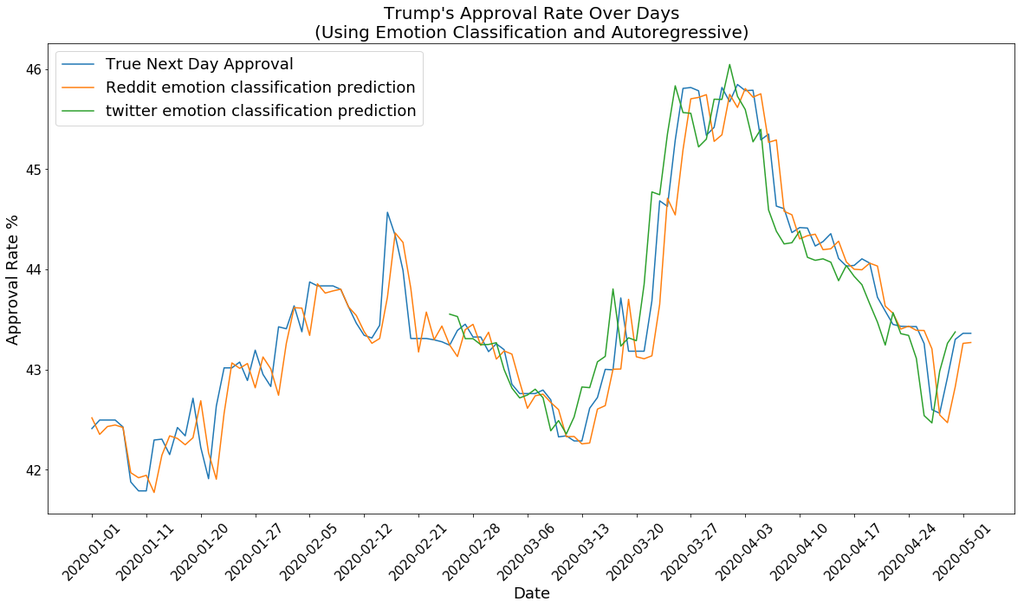

```python
fig, ax = plt.subplots(1, figsize = (20, 10))
ax.plot(pred_result.true_next_app, label = 'True Next Day Approval')
ax.plot(pred_result.reddit_pred, label = 'Reddit emotion classification prediction')
ax.plot(pred_result.twitter_pred, label = 'twitter emotion classification prediction')
tic = []
labe = []
for i in range(len(pred_result.index)):
    if i % 7 == 0:
        tic.append(pred_result.index[i])
        labe.append(str(pred_result.index[i])[:10])
plt.xticks(tic, labe, rotation = 45, fontsize = '15')
plt.yticks(fontsize = '15')
ax.legend(fontsize = '18')
plt.title('Trump\'s Approval Rate Over Days\n(Using Emotion Classification and Autoregressive)', fontsize = '20')
plt.xlabel('Date', fontsize = '18')
plt.ylabel('Approval Rate %', fontsize = '18')
#plt.grid()
plt.show()
```

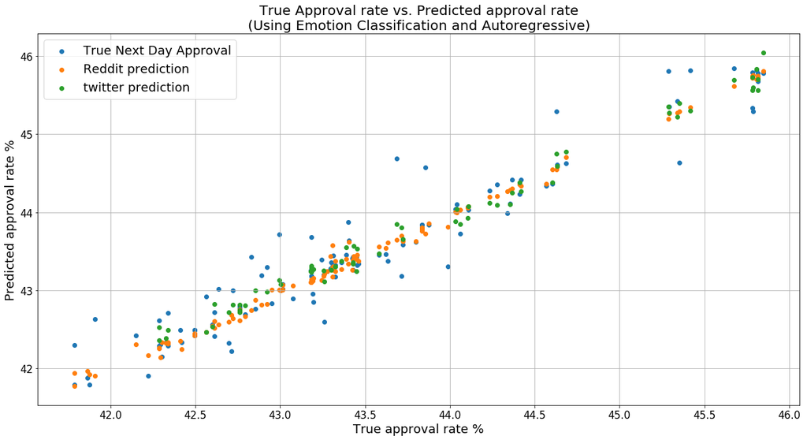

```python
fig, ax = plt.subplots(1, figsize = (20, 10))
ax.scatter(rd_auto.app, pred_result.true_next_app, label = 'True Next Day Approval')
ax.scatter(rd_auto.app,pred_result.reddit_pred, label = 'Reddit prediction')
ax.scatter(td_auto.app, t_p, label = 'twitter prediction')
plt.title('True Approval rate vs. Predicted approval rate\n(Using Emotion Classification and Autoregressive)', fontsize = '20')
plt.xlabel('True approval rate %', fontsize = '18')
plt.ylabel('Predicted approval rate %', fontsize = '18')
plt.yticks(fontsize = '15')
plt.xticks(fontsize = '15')
ax.legend(fontsize = '18')
plt.grid()
plt.show()
```

```python
print('Twitter emotion classification prediction MSE:',metrics.mean_squared_error(td_auto.app, t_p))
print('Twitter emotion classification prediction RMSE:',np.sqrt(metrics.mean_squared_error(td_auto.app, t_p)))
print('Twitter emotion classification prediction R^2:',metrics.r2_score(td_auto.app, t_p))
print('\n')
print('Reddit emotion classification prediction MSE:',metrics.mean_squared_error(pred_result.true_next_app,pred_result.reddit_pred))
print('Reddit emotion classification prediction RMSE:',np.sqrt(metrics.mean_squared_error(pred_result.true_next_app,pred_result.reddit_pred)))
print('Reddit emotion classification prediction R^2:',metrics.r2_score(pred_result.true_next_app,pred_result.reddit_pred))
```

```
Twitter emotion classification prediction MSE: 0.01509842181102854
Twitter emotion classification prediction RMSE: 0.12287563554679398
Twitter emotion classification prediction R^2: 0.986791165703465


Reddit emotion classification prediction MSE: 0.08625287223792094
Reddit emotion classification prediction RMSE: 0.2936883930936341
Reddit emotion classification prediction R^2: 0.9146325895160442
```

### #5 SVR-RBF model with aggragated text vectors

##### We aggregated the word vector for both dataset and noralized them, but we are not able to show the process due to the size of dataset is not able to be decreased, so we will only post results here.

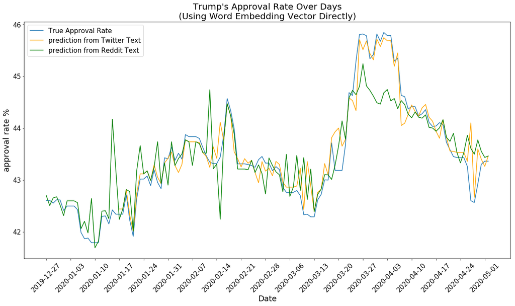

```python
from IPython.display import Image
Image("img/Embed Model Plot.png")
```

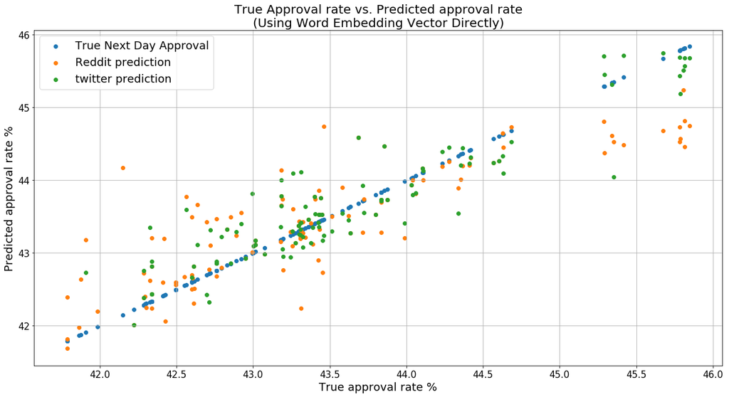

```python
Image("img/Embed Model Scatter.png")
```

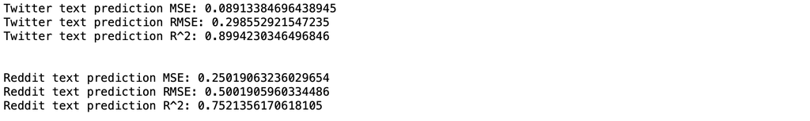

```python
Image("img/Embed Model stats.png")
```

### #6 Autoregressive SVR-RBF model with aggragated text vectors

##### Then we thought that could we combine the autoregressive and the word embedding vector methods together? We tried! And got a good result!

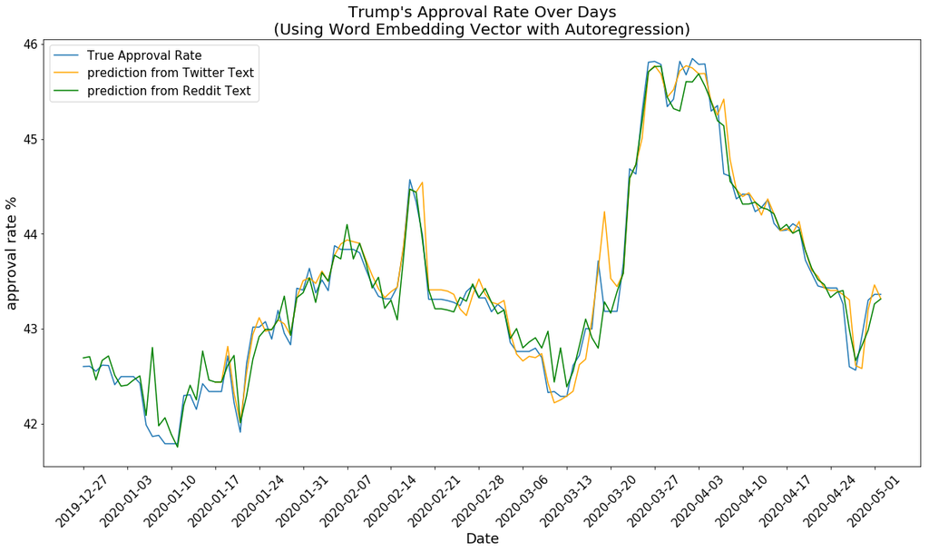

```python
Image("img/auto Embed Model plot.png")
```

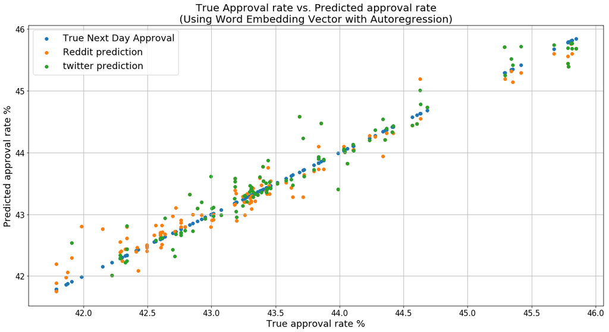

```python
Image("img/auto Embed Model scatter.png")
```

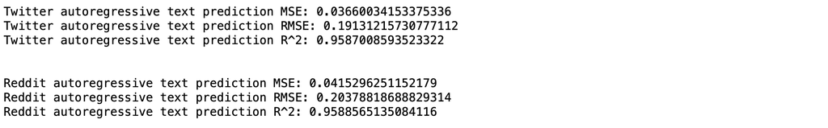

```python
Image("img/auto Embed Model stats.png")
```

#### As a conclusion, our final model has the best average performance on both dataset